# Visualizations with statistical details: The ‘ggstatsplot’ approach

# Summary

Graphical displays can reveal problems in a statistical model that might not be apparent from purely numerical summaries. Such visualizations can also be helpful for the reader to evaluate the validity of a model if it is reported in a scholarly publication or report. But, given the onerous costs involved, researchers often avoid preparing information-rich graphics and exploring several statistical approaches or tests available. The `{ggstatsplot}` package in the R programming language (R Core Team, 2021) provides a one-line syntax to enrich `{ggplot2}`-based visualizations with the results from statistical analysis embedded in the visualization itself. In doing so, the package helps researchers adopt a rigorous, reliable, and robust data exploratory and reporting workflow.

# Statement of Need

In a typical data analysis workflow, data visualization and statistical modeling are two different phases: visualization informs modeling, and in turn, modeling can suggest a different visualization method, and so on and so forth (Wickham & Grolemund, 2016). The central idea of `{ggstatsplot}` is simple: combine these two phases into one in the form of an informative graphic with statistical details.

Before discussing benefits of this approach, we will show an example (Figure 1).

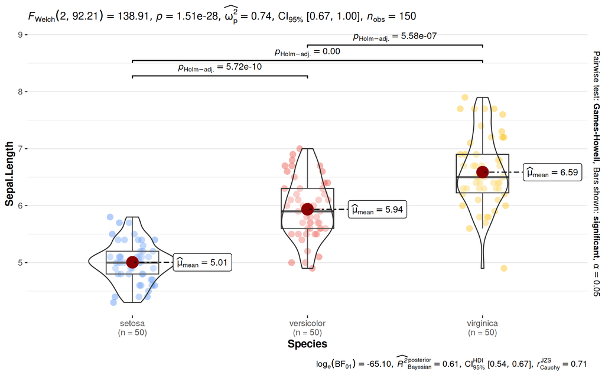

```r
ggbetweenstats(iris, Species, Sepal.Length)
```

As can be seen, with a single line of code, the function produces details about descriptive statistics, inferential statistics, effect size estimate and its uncertainty, pairwise comparisons, Bayesian hypothesis testing, Bayesian posterior estimate and its uncertainty. Moreover, these details are juxtaposed with informative and well-labeled visualizations. The defaults are designed to follow best practices in both data visualization (Cleveland, 1985; Grant, 2018; Healy, 2018; Tufte, 2001; Wilke, 2019) and (frequentist/Bayesian) statistical reporting (American Psychological Association, 2019; van Doorn et al., 2021). Without `{ggstatsplot}`, getting these statistical details and customizing a plot would require a significant amount of time and effort. In other words, this package removes the trade-off often faced by researchers between ease and thoroughness of data exploration and further cements good data exploration habits.

Internally, data cleaning is carried out using the `tidyverse` (Wickham et al., 2019), while statistical analysis is carried out via the `{statsExpressions}` (Patil, 2021) and `easystats` (Ben-Shachar et al., 2020; Lüdecke et al., 2019, 2020, 2021; Makowski et al., 2019, 2020) packages. All visualizations are constructed using the grammar of graphics framework (Wilkinson, 2012), as implemented in the `{ggplot2}` package (Wickham, 2016).

# Benefits

In summary, the benefits of `{ggstatsplot}`’s approach are the following. It:

[figure not shown]

# Future Scope

This package is an ambitious, ongoing, and long-term project. It currently supports common statistical tests (parametric, non-parametric, robust, or Bayesian *t*-test, one-way ANOVA, contingency table analysis, correlation analysis, meta-analysis, regression analyses, etc.) and corresponding visualizations (box/violin plot, scatter plot, dot-and-whisker plot, pie chart, bar chart, etc.). It will continue expanding to support an increasing collection of statistical analyses and visualizations.

# Learn More

- Articles for each function, frequently asked questions, and other topics are available on the package website: https://www.indrapatil.com/ggstatsplot/articles/
- The statistical details displayed in any plot can be retrieved as data frames with `extract_stats()` (and the expressions with `extract_subtitle()` and `extract_caption()`), e.g. `extract_stats(ggbetweenstats(iris, Species, Sepal.Length))`.

# Licensing and Availability

`{ggstatsplot}` is licensed under the MIT License, with all source code stored at [GitHub](https://github.com/IndrajeetPatil/ggstatsplot/). In the spirit of honest and open science, requests and suggestions for fixes, feature updates, as well as general questions and concerns are encouraged via direct interaction with contributors and developers by filing an [issue](https://github.com/IndrajeetPatil/ggstatsplot/issues).

# Acknowledgements

I would like to acknowledge the support of Mina Cikara, Fiery Cushman, and Iyad Rahwan during the development of this project. `{ggstatsplot}` relies heavily on the [`easystats`](https://github.com/easystats/easystats) ecosystem, a collaborative project created to facilitate the usage of `R` for statistical analyses. Thus, I would like to thank the [members](https://github.com/orgs/easystats/people) of `easystats` as well as the users. I would additionally like to thank the contributors to `{ggstatsplot}` for reporting bugs, providing helpful feedback, or helping with enhancements.

# Citation

This vignette can be cited as:

```
  Patil, I. (2021). Visualizations with statistical details: The
  'ggstatsplot' approach. Journal of Open Source Software, 6(61), 3167,
  doi:10.21105/joss.03167

A BibTeX entry for LaTeX users is

  @Article{,
    doi = {10.21105/joss.03167},
    url = {https://doi.org/10.21105/joss.03167},
    year = {2021},
    publisher = {{The Open Journal}},
    volume = {6},
    number = {61},
    pages = {3167},
    author = {Indrajeet Patil},
    title = {{Visualizations with statistical details: The {'ggstatsplot'} approach}},
    journal = {{Journal of Open Source Software}},
  }
```

# References

American Psychological Association. (2019). *Publication Manual of the American Psychological Association, 7th Edition*. American Psychological Association.

Ben-Shachar, M. S., Lüdecke, D., & Makowski, D. (2020). effectsize: Estimation of effect size indices and standardized parameters. *Journal of Open Source Software*, *5*(56), 2815. https://doi.org/10.21105/joss.02815

Cleveland, W. S. (1985). *The Elements of Graphing Data* (1st edition). Wadsworth, Inc.

Grant, R. (2018). *Data Visualization: Charts, Maps, and Interactive Graphics*. CRC Press.

Healy, K. (2018). *Data Visualization: A Practical Introduction*. Princeton University Press.

Lüdecke, D., Ben-Shachar, M. S., Patil, I., & Makowski, D. (2020). Extracting, computing and exploring the parameters of statistical models using R. *Journal of Open Source Software*, *5*(53), 2445. https://doi.org/10.21105/joss.02445

Lüdecke, D., Ben-Shachar, M. S., Patil, I., Waggoner, P., & Makowski, D. (2021). performance: An R package for assessment, comparison and testing of statistical models. *Journal of Open Source Software*, *6*(60), 3139. https://doi.org/10.21105/joss.03139

Lüdecke, D., Waggoner, P., & Makowski, D. (2019). Insight: A unified interface to access information from model objects in R. *Journal of Open Source Software*, *4*(38), 1412. https://doi.org/10.21105/joss.01412

Makowski, D., Ben-Shachar, M. S., & Lüdecke, D. (2019). bayestestR: Describing effects and their uncertainty, existence and significance within the Bayesian framework. *Journal of Open Source Software*, *4*(40), 1541. https://doi.org/10.21105/joss.01541

Makowski, D., Ben-Shachar, M. S., Patil, I., & Lüdecke, D. (2020). Methods and algorithms for correlation analysis in R. *Journal of Open Source Software*, *5*(51), 2306. https://doi.org/10.21105/joss.02306

Patil, I. (2021). statsExpressions: R Package for Tidy Dataframes and Expressions with Statistical Details. *Journal of Open Source Software*, *6*(61), 3236. https://doi.org/10.21105/joss.03236

R Core Team. (2021). *R: A language and environment for statistical computing*. R Foundation for Statistical Computing. https://www.R-project.org/

Tufte, E. R. (2001). *The Visual Display of Quantitative Information* (2nd edition). Graphics Press.

van Doorn, J., van den Bergh, D., Böhm, U., Dablander, F., Derks, K., Draws, T., Etz, A., Evans, N. J., Gronau, Q. F., Haaf, J. M., Hinne, M., Kucharský, Š., Ly, A., Marsman, M., Matzke, D., Gupta, A. R. K. N., Sarafoglou, A., Stefan, A., Voelkel, J. G., & Wagenmakers, E.-J. (2021). The JASP guidelines for conducting and reporting a Bayesian analysis. *Psychonomic Bulletin & Review*, *28*(3), 813–826. https://doi.org/10.3758/s13423-020-01798-5

Wickham, H. (2016). *ggplot2: Elegant graphics for data analysis*. Springer-Verlag New York.

Wickham, H., Averick, M., Bryan, J., Chang, W., McGowan, L. D., François, R., Grolemund, G., Hayes, A., Henry, L., Hester, J., Kuhn, M., Pedersen, T. L., Miller, E., Bache, S. M., Müller, K., Ooms, J., Robinson, D., Seidel, D. P., Spinu, V., … Yutani, H. (2019). Welcome to the tidyverse. *Journal of Open Source Software*, *4*(43), 1686. https://doi.org/10.21105/joss.01686

Wickham, H., & Grolemund, G. (2016). *R for Data Science*. O’Reilly Media.

Wilke, C. O. (2019). *Fundamentals of Data Visualization*. O’Reilly Media.

Wilkinson, L. (2012). The Grammar of Graphics. In *Handbook of computational statistics* (pp. 375–414). Springer.